# Practical Machine Learning: Project

B. Karahadian

5/19/2021

The purpose of this project is to successfully fit a machine learning algorithm to the HAR (Human Activity Recognition) Weight Lifting dataset. In this dataset, participants were equipped with activity monitors while they performed 5 different movements: perfect dumbbell curl (classe = A) and imperfect dumbbell curls (classe = B, C, D, E). Using the metrics generated by the activity monitors, we will create an algorithm that can successfully predict which motion the participant is conducting.

## Exploration and Cleaning

```r
library(tidyverse)
library(caret)
```

First, let’s load the data and take a preliminary look at them.

```r
train <- read_csv("pml-training.csv")
test <- read_csv("pml-testing.csv")

train
```

```
## # A tibble: 19,622 x 160
##       X1 user_name raw_timestamp_pa… raw_timestamp_pa… cvtd_timestamp new_window
##    <dbl> <chr>                 <dbl>             <dbl> <chr>          <chr>
##  1     1 carlitos         1323084231            788290 05/12/2011 11… no
##  2     2 carlitos         1323084231            808298 05/12/2011 11… no
##  3     3 carlitos         1323084231            820366 05/12/2011 11… no
##  4     4 carlitos         1323084232            120339 05/12/2011 11… no
##  5     5 carlitos         1323084232            196328 05/12/2011 11… no
##  6     6 carlitos         1323084232            304277 05/12/2011 11… no
##  7     7 carlitos         1323084232            368296 05/12/2011 11… no
##  8     8 carlitos         1323084232            440390 05/12/2011 11… no
##  9     9 carlitos         1323084232            484323 05/12/2011 11… no
## 10    10 carlitos         1323084232            484434 05/12/2011 11… no
## # … with 19,612 more rows, and 154 more variables: num_window <dbl>,
## #   roll_belt <dbl>, pitch_belt <dbl>, yaw_belt <dbl>, total_accel_belt <dbl>,
## #   kurtosis_roll_belt <chr>, kurtosis_picth_belt <chr>,
## #   kurtosis_yaw_belt <chr>, skewness_roll_belt <chr>,
## #   skewness_roll_belt.1 <chr>, skewness_yaw_belt <chr>, max_roll_belt <dbl>,
## #   max_picth_belt <dbl>, max_yaw_belt <chr>, min_roll_belt <dbl>,
## #   min_pitch_belt <dbl>, min_yaw_belt <chr>, amplitude_roll_belt <dbl>,
## #   amplitude_pitch_belt <dbl>, amplitude_yaw_belt <chr>,
## #   var_total_accel_belt <dbl>, avg_roll_belt <dbl>, stddev_roll_belt <dbl>,
## #   var_roll_belt <dbl>, avg_pitch_belt <dbl>, stddev_pitch_belt <dbl>,
## #   var_pitch_belt <dbl>, avg_yaw_belt <dbl>, stddev_yaw_belt <dbl>,
## #   var_yaw_belt <dbl>, gyros_belt_x <dbl>, gyros_belt_y <dbl>,
## #   gyros_belt_z <dbl>, accel_belt_x <dbl>, accel_belt_y <dbl>,
## #   accel_belt_z <dbl>, magnet_belt_x <dbl>, magnet_belt_y <dbl>,
## #   magnet_belt_z <dbl>, roll_arm <dbl>, pitch_arm <dbl>, yaw_arm <dbl>,
## #   total_accel_arm <dbl>, var_accel_arm <dbl>, avg_roll_arm <dbl>,
## #   stddev_roll_arm <dbl>, var_roll_arm <dbl>, avg_pitch_arm <dbl>,
## #   stddev_pitch_arm <dbl>, var_pitch_arm <dbl>, avg_yaw_arm <dbl>,
## #   stddev_yaw_arm <dbl>, var_yaw_arm <dbl>, gyros_arm_x <dbl>,
## #   gyros_arm_y <dbl>, gyros_arm_z <dbl>, accel_arm_x <dbl>, accel_arm_y <dbl>,
## #   accel_arm_z <dbl>, magnet_arm_x <dbl>, magnet_arm_y <dbl>,
## #   magnet_arm_z <dbl>, kurtosis_roll_arm <dbl>, kurtosis_picth_arm <chr>,
## #   kurtosis_yaw_arm <chr>, skewness_roll_arm <dbl>, skewness_pitch_arm <chr>,
## #   skewness_yaw_arm <chr>, max_roll_arm <dbl>, max_picth_arm <dbl>,
## #   max_yaw_arm <dbl>, min_roll_arm <dbl>, min_pitch_arm <dbl>,
## #   min_yaw_arm <dbl>, amplitude_roll_arm <dbl>, amplitude_pitch_arm <dbl>,
## #   amplitude_yaw_arm <dbl>, roll_dumbbell <dbl>, pitch_dumbbell <dbl>,
## #   yaw_dumbbell <dbl>, kurtosis_roll_dumbbell <dbl>,
## #   kurtosis_picth_dumbbell <dbl>, kurtosis_yaw_dumbbell <chr>,
## #   skewness_roll_dumbbell <dbl>, skewness_pitch_dumbbell <dbl>,
## #   skewness_yaw_dumbbell <chr>, max_roll_dumbbell <dbl>,
## #   max_picth_dumbbell <dbl>, max_yaw_dumbbell <dbl>, min_roll_dumbbell <dbl>,
## #   min_pitch_dumbbell <dbl>, min_yaw_dumbbell <dbl>,
## #   amplitude_roll_dumbbell <dbl>, amplitude_pitch_dumbbell <dbl>,
## #   amplitude_yaw_dumbbell <dbl>, total_accel_dumbbell <dbl>,
## #   var_accel_dumbbell <dbl>, avg_roll_dumbbell <dbl>,
## #   stddev_roll_dumbbell <dbl>, var_roll_dumbbell <dbl>, …
```

Here we can see the total counts of the different classes throughout the training data:

```r
train %>%
    count(classe)
```

```
## # A tibble: 5 x 2
##   classe     n
##   <chr>  <int>
## 1 A       5580
## 2 B       3797
## 3 C       3422
## 4 D       3216
## 5 E       3607
```

As we can see, each class is sufficiently represented to not have to worry about weights when modeling.

The variables “user_name” and “X1”, the name of the participant and the observation number, respectively, will not help us with prediction so we can remove them. Neither will the timestamp variables provide any predictive value.

```r
train <-
    train %>%
    select(-X1, -user_name, -raw_timestamp_part_1, -raw_timestamp_part_2, -cvtd_timestamp)
```

As we can see, there are multiple variables that are nearly completely populated with NA’s.

```r
map_dbl(train, function(x) {
    is.na(x) %>%
        sum()
}) %>%
    head(25)
```

```
##           new_window           num_window            roll_belt
##                    0                    0                    0
##           pitch_belt             yaw_belt     total_accel_belt
##                    0                    0                    0
##   kurtosis_roll_belt  kurtosis_picth_belt    kurtosis_yaw_belt
##                19216                19216                19216
##   skewness_roll_belt skewness_roll_belt.1    skewness_yaw_belt
##                19216                19216                19216
##        max_roll_belt       max_picth_belt         max_yaw_belt
##                19216                19216                19216
##        min_roll_belt       min_pitch_belt         min_yaw_belt
##                19216                19216                19216
##  amplitude_roll_belt amplitude_pitch_belt   amplitude_yaw_belt
##                19216                19216                19216
## var_total_accel_belt        avg_roll_belt     stddev_roll_belt
##                19216                19216                19216
##        var_roll_belt
##                19216
```

These variables should be removed from our dataset.

```r
na_vars <-
    map_dbl(train, function(x) {
        is.na(x) %>%
            sum()
    }) %>%
        `>`(0) %>%
        which()

train <-
    train %>%
        select(-all_of(na_vars))
```

## Modeling

To model these data, we will first generate three separate models: a random forest, a boosted decision tree, and a radial support vector machine. Then we will stack these models to see if we can eke out some more predictive power. First, we split the training data into three different sections, so we can validate our two tiers of models.

```r
set.seed(1111)
inds <- createDataPartition(train$classe, times = 1, p = 0.5)
train2 <- train[inds[[1]],]
out <- train[-inds[[1]],]

set.seed(2222)
inds_out <- createDataPartition(out$classe, times = 1, 0.9)
valid <- out[inds_out[[1]],]
est_test <- out[-inds_out[[1]],]
```

Now, we will train the three individual models on the “train2” data. Note that we use 10-fold cross validation to tune the parameters of the models. A bootstrapping method may yield more highly optimized results, but my local machine is not up to that computational task.

```r
mod_rf <-
    train(classe ~ ., data = train2, method = "rf",
          trControl = trainControl(method = "cv", number = 10))

mod_boost <-
    train(classe ~ ., data = train2, method = "AdaBoost.M1",
          trControl = trainControl(method = "cv", number = 10))

mod_svm <-
    train(classe ~ ., data = train2, method = "svmRadial",
          trControl = trainControl(method = "cv", number = 10))
```

### Random Forest

Here is the prediction accuracy for our random forest algorithm evaluated on the left-out validation set:

```r
valid %>%
    mutate(rf_preds = predict(mod_rf, valid)) %>%
    summarize(mean(rf_preds == classe))
```

```
## # A tibble: 1 x 1
##   `mean(rf_preds == classe)`
##                        <dbl>
## 1                      0.995
```

It is very accurate. As we can see from this diagnostic plot, the algorithm maxes out its accuracy at 28 randomly selected predictors per tree.

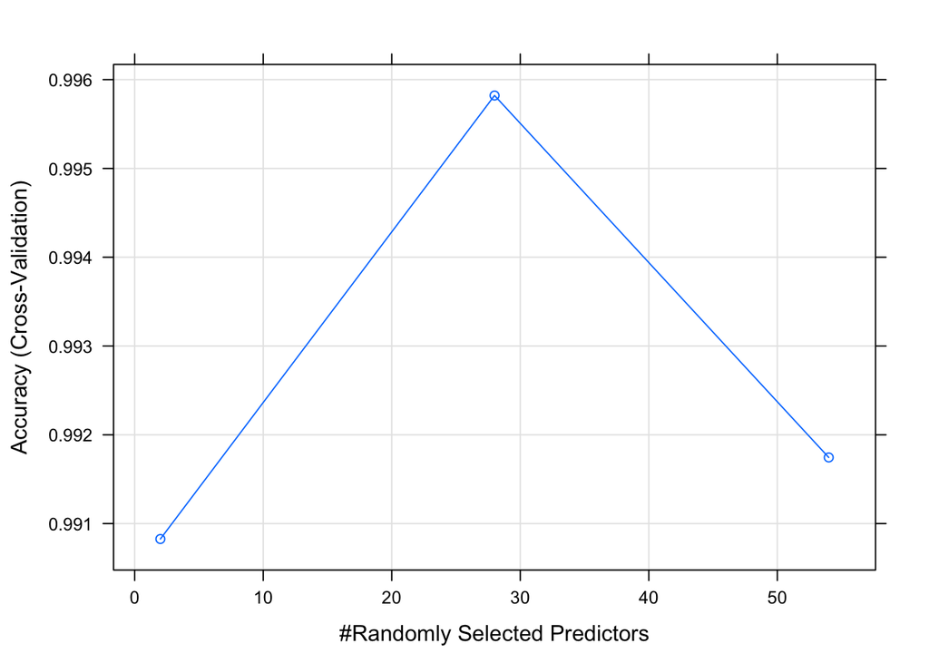

```r
plot.train(mod_rf)
```

### Boosted Tree

Here is the prediction accuracy for our boosted decision tree evaluated on the left-out validation set:

```r
valid %>%
    mutate(boost_preds = predict(mod_boost, valid)) %>%
    summarize(mean(boost_preds == classe))
```

```
## # A tibble: 1 x 1
##   `mean(boost_preds == classe)`
##                           <dbl>
## 1                         0.967
```

It is also very accurate, but not quite as good the random forest.

As we can see from this diagnotic plot, the algorith maxes out its accuracy using the Zhu method, a maximum tree-depth of 3, and over 140 trees.

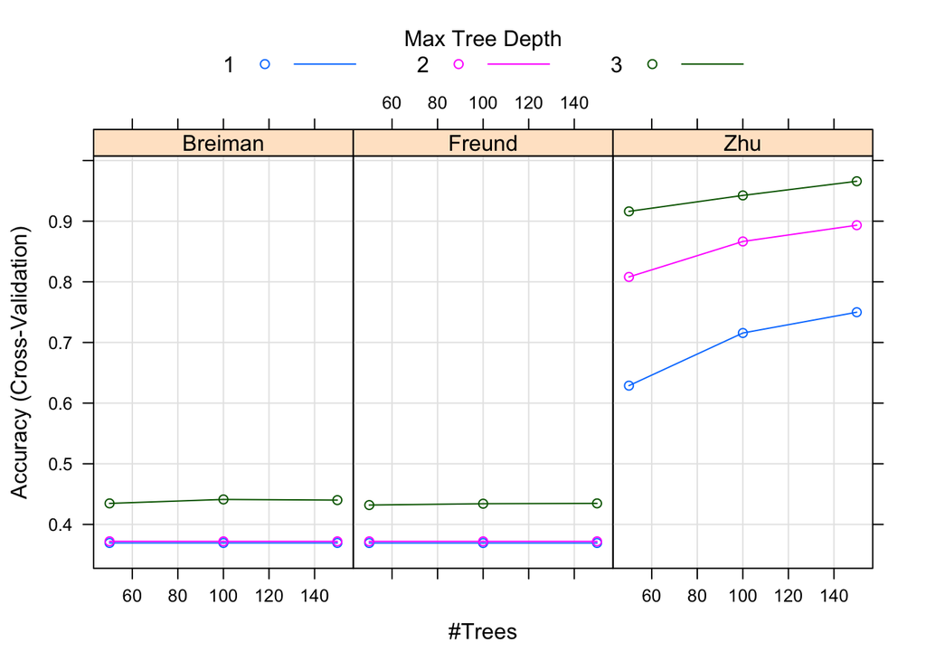

```r
plot.train(mod_boost)
```

### SVM

Here is the prediction accuracy for our radial support vector machine evaluated on the left-out validation set:

```r
valid %>%
    mutate(svm_preds = predict(mod_svm, valid)) %>%
    summarize(mean(svm_preds == classe))
```

```
## # A tibble: 1 x 1
##   `mean(svm_preds == classe)`
##                         <dbl>
## 1                       0.912
```

As before, this model is very accurate but not quite as good as the two previous.

As we can see from this diagnostic plot, the algorithm maxes out its accuracy with a cost hyperparameter of 1.

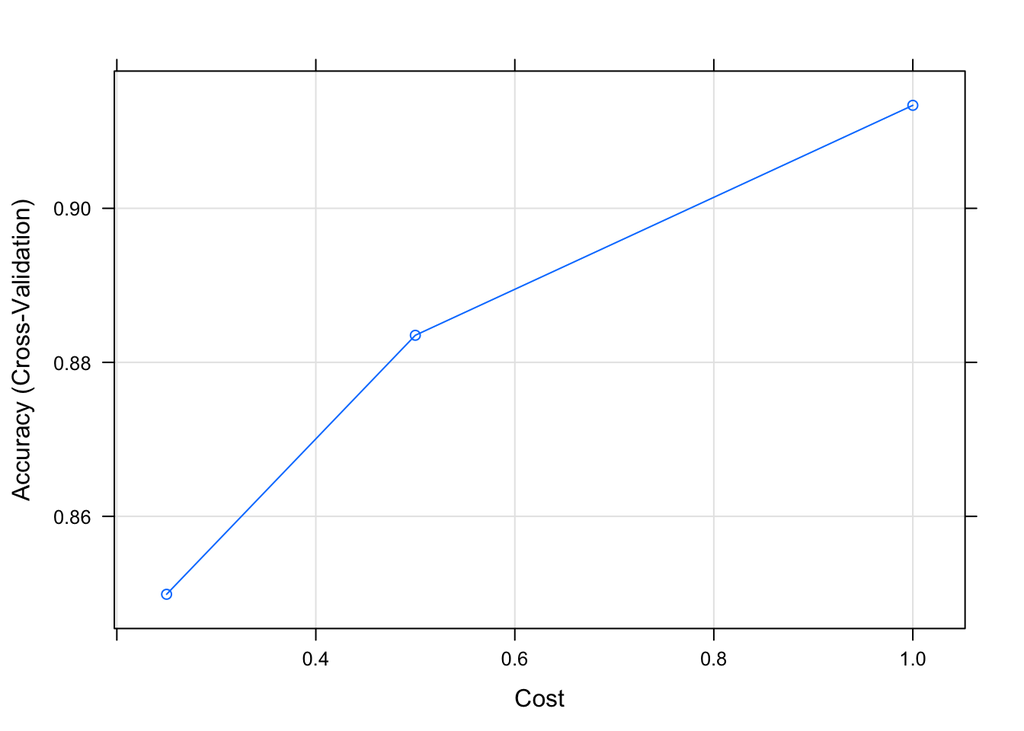

```r
plot.train(mod_svm)
```

### Stacked Model

Now, we will use the predictions from these three models to train a stacked random forest algorithm to try to beat the predicton accuracy of the single random forest model.

```r
valid <-
    valid %>%
        mutate(rf_preds = predict(mod_rf, valid),
               boost_preds = predict(mod_boost, valid),
               svm_preds = predict(mod_svm, valid))

mod_stack <- train(classe ~ rf_preds + boost_preds + svm_preds, data = valid, method = "rf",
                   trControl = trainControl(method = "cv", number = 10))
```

Here is its prediction accuracy:

```r
est_test <-
    est_test %>%
        mutate(rf_preds = predict(mod_rf, est_test),
               boost_preds = predict(mod_boost, est_test),
               svm_preds = predict(mod_svm, est_test))

est_test %>%
    mutate(stack_preds = predict(mod_stack, est_test)) %>%
    summarize(mean(stack_preds == classe))
```

```
## # A tibble: 1 x 1
##   `mean(stack_preds == classe)`
##                           <dbl>
## 1                         0.997
```

It beats the single random forest model by 0.002. Not much of an improvement, but 0.997 is pretty damn good.